# Économétrie — TD 1

Introduction & EViews : prise en main

Pierre Beaucoral

# 1 Objectifs

- Comprendre la base de l’économétrie
- Prendre en main **EViews**
- Préparer la **base pour les futurs TDs**

# 2 Introduction

- L’économétrie s’inscrit dans une démarche scientifique dite **hypothético-déductive** (Popper)

[figure not shown]

- L’économétrie est une méthode d’analyse des données des phénomènes économiques qui, par l’utilisation de la statistique et des mathématiques, établit des corrélations entre les variables.
- Objectifs :

  ▶ Tester la véracité empirique d’une théorie

  ▶ Prévoir l’évolution d’un phénomène

  ▶ Calculer la valeur de paramètres des modèles théoriques

## 2.1 Corrélation et causalité

Corrélation n’est pas synonyme de causalité, or l’économétrie ne mesure que des corrélations!

**Note**

Preuve, ce [site web](https://www.tylervigen.com/spurious-correlations) (cliquer si temps disponible)

## 2.2 Principe de l’économétrie

`Principe` : Vous disposez d’une variable à expliquer (l*e nombre de buts)* et d’une [ou plusieurs] variable[s] explicative[s] (*poste du joueur, taille, club*) et vous essayez de savoir s’il existe une relation entre celles-ci.

**Tip**

Avec un apport théorique préalable, une corrélation peut être suspectée de causale.

`Cours`:

▶ Présentation des concepts en CM (M. Brun)

▶ Mise en pratique sur EViews en TD

## 2.3 Plan du cours

`Nos séances de TD :`

▶ TD 1 : Présentation et prise en main d’EViews

▶ TD 2 : Gestion et explorations de la base de données

▶ TD 3 : **Modèle linéaire (MCO)** et conditions de validité.

▶ TD 4 : **Tests d’hypothèses économétriques** : homoscédasticité (Goldfeld–Quandt, Breusch–Pagan, White) et corrections pour l’hétéroscédasticité (White).

▶ TD 5 : **Tests d’hypothèses économiques** : stabilité des coefficients et pertinence de l’estimation & autocorrélation.

▶ TD 6 : **Variables instrumentales (2SLS)** : identification, exogénéité et instrumentation (test de Hausman — principe Nakamura & Nakamura).

▶ TD 7: **Variables instrumentales (2SLS)** : avancé.

▶ TD 8 : **Normalité des erreurs** : normalité (Jarque–Bera).

▶ TD 9: **Simulation de Monte Carlo.**

## 2.4 Les données utilisées en économétrie

Les données utilisées en économétrie sont de trois types :

1. Données **transversales** :

Données sur **plusieurs** individus à **un** instant donné

2. Données **temporelles** :

Données sur **un** seul individu à **des** périodes différentes

3. Données de **panel** :

Données enregistrées pour **différents** individus à **différentes** périodes

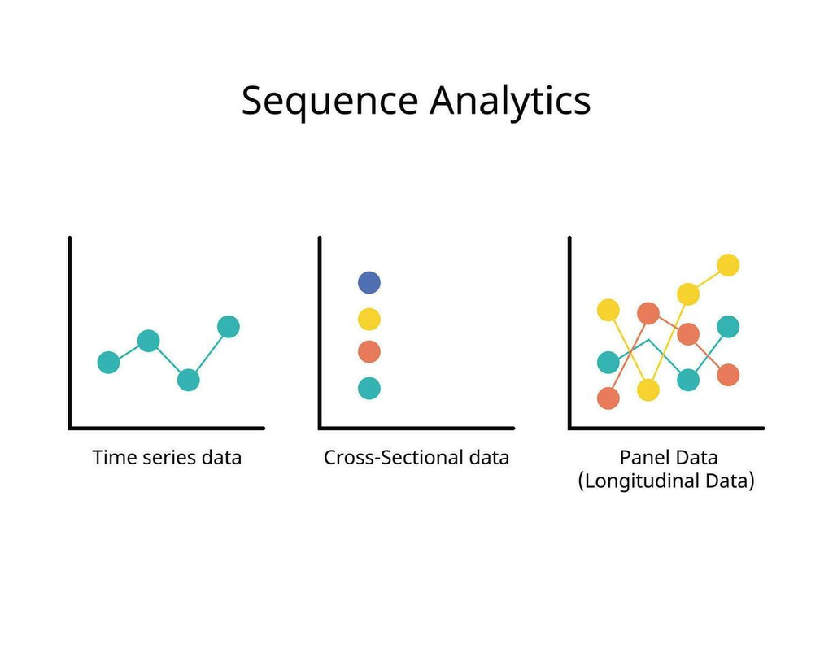

**Important**

Dans le cadre de ce cours, nous travaillerons uniquement sur des données transversales.

# 3 Travailler sous EViews

## 3.1 EViews — Environnement

EViews est un logiciel développé par *Quantitative Micro Software*

Il existe de nombreux autres logiciels d’économétrie.

> Les plus utilisés sont [stata](https://www.stata.com/) ou [R](https://www.r-project.org/)

`Avantages d’EViews :`

▶ Simple d’utilisation (fonctionnement avec une interface)

▶ Performant pour les séries temporelles

`Inconvénients :`

▶ Il s’agit uniquement d’un logiciel d’économétrie

La traitement de données doit être fait au préalable

▶ Peu flexible

## 3.2 Environnement et logique de fonctionnement

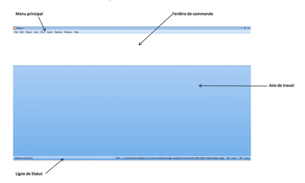

## 3.3 Environnement et logique de fonctionnement

Trois manières de travailler sous EViews :

- 1. Par l’interface graphique
- 2. En rentrant le nom de la commande dans la fenêtre de commande
- 3. En regroupant les commandes dans un programme

**Important**

Dans le cadre de ce cours, nous utiliserons les deux premières méthodes

## 3.4 Les différents types de fichiers

1. **Fichier texte (.txt) ou Excel (.xls)** : contient la base de données
2. **Fichier workfile (.wf1)** : enregistre le travail
3. **Fichier programme (.prg)** : enregistre le programme *(non utilisé ici)*

## 3.5 Les différents types d’objets

Un objet est un élément stockant différents types d’informations, rassemblés dans le **workfile**.  
Double-cliquer sur l’icône pour l’ouvrir.

- Objets les plus fréquents :
  - Variables numériques
  - Liste d’éléments en texte
  - Équation
  - Graphique
  - Coefficients et résidus estimés
  - Scalaire et matrices

## 3.6 Création du workfile (.wf1)

Première étape avant d’importer une base de données.

Menu : **File → New → Workfile**

- Trois structures possibles :
  1. **Unstructured/Undated** (données transversales)
  2. **Dated–regular frequency** (données temporelles)
  3. **Balanced Panel** (données de panel)
- Noms des paramètres:
  - *Data Range* : nombre d’observations (ex. nombre de pays) - *Frequency* : fréquence des données (annuelle, …)
  - *Start date* : date initiale (ex. 1970)
  - *End date* : date de fin (ex. 2008)
  - *Frequency, Start date, End date* : cf. ci-dessus
  - *Number of Cross-section* : nombre d’individus

## 3.7 Création du workfile (.wf1)

**Modules optionnels :**

- *Name* : nom du workfile
- *Page* : numéro de page

**Sauvegarde :**

- Première sauvegarde :

  **File → Save as** - Ensuite : **File → Save** ou **Ctrl+S**
- **Ouvrir un workfile existant :**

  **File → Open → Workfile** **→**Choisir le fichier à ouvrir

## 3.8 Importation de données

**Caution**

**Préalable :** Seules les données sont acceptées (le fichier Excel ne doit pas contenir de formules).

**Procédure:**

1. Fermer la feuille Excel
2. **File → Import → Import from file**
3. Sélectionner le fichier (base de données)

**Une première fenêtre s’ouvre :**

- *Predefined Range* : aucun changement
- *Custom range* : pour modifier la feuille, la première et la dernière cellule

**Puis une deuxième fenêtre permet de modifier :**

- Nb de lignes définissant le statut (*Column headers*)
- Nom et type des variables et leurs labels (*Column info*)

Une troisième fenêtre offre des opérations plus complexes (lier différentes bases de données).

**Terminer** puis sauvegarder le workfile (**File → Save** ou **Ctrl+S**).

## 3.9 Création du workfile et importation en une étape

Possible via : **File → Open → Foreign Data as Workfile**

**Avantage :**

- Gain de temps

**Inconvénient :**

- La base doit être parfaitement préparée.

# 4 Exercice

## 4.1 Q.0.1 — Types de données en économétrie

**Question :** Quelles sont les trois grandes catégories de données ?

**Afficher la réponse**

- **Transversales** : plusieurs individus, une date donnée.
- **Temporelles** : une unité observée sur plusieurs dates.
- **Panel** : plusieurs individus suivis sur plusieurs dates.

## 4.2 Q.0.2 — Corrélation et causalité

**Question :** La corrélation implique-t-elle une causalité ?

**Afficher la réponse**

Non.  
- Corrélation : deux variables évoluent ensemble.  
- Causalité : une variable **provoque** l’évolution de l’autre.  
*Exemple* : Fumer ↦ augmentation du risque de cancer du poumon.

## 4.3 Q1 — Création du Workfile

**Question :** Comment créer un *workfile* pour accueillir des données transversales dans EViews ?

**Afficher la réponse**

1. Menu **File → New → Workfile**
2. Choisir **Unstructured / Undated**
3. Indiquer le **nombre d’observations** (ex. 94)
4. **File → Save as** pour enregistrer.

## 4.4 Q2 — Importation de données Excel

**Question :** Quelle est la procédure pour importer un fichier Excel dans EViews ?

**Afficher la réponse**

1. **Fermer** le fichier Excel.
2. Dans EViews : **File → Import → Import from file**.
3. Sélectionner le fichier `TD1.xls`.
4. Vérifier la plage de données puis valider.
5. Sauvegarder le *workfile*.

## 4.5 Q3 — Nature des variables

**Question :** Pourquoi la variable `Compagnie` apparaît en texte? La variable `Public` ?

**Afficher la réponse**

- `Compagnie` : **variable qualitative nominale** (noms de compagnies).
- `Public` : **variable binaire** (oui/non)

## 4.6 Q4 — Modifier la base

**Question :** Faites les modifications nécessaires afin de rendre la base de données exploitable.

**Afficher la réponse**

- `Public` : **variable binaire** (oui/non) ⇒ à recoder en 0/1 si nécessaire.

`genr dummy_public = @recode(public="yes", 1, 0)`

- `Indice` : Regarder la variable `intercontinental`.